# Nitrogen isotopes and land-use sources of coastal nitrate

## 2.5 Literature-informed priors

Rule (set before looking at the sample data): within each group, an entry’s mean is its reported mean, or the midpoint of a reported range; its SD is the reported SD, or (max - min) / 4 for a range. Derived values are approximations, and range / 4 overstates SD for skewed distributions. The group mean is the average of entry means. Between-study variation is the SD of entry means; within-source variation is the root-mean-square of entry SDs (entries reporting a single value contribute no SD). The source distribution used later is Normal(group mean, source SD), where source SD combines both. The uncertainty in the group mean is between-study SD / sqrt(k). Rows tagged `wastewater;manure` count in both groups because the literature treats human and animal waste nitrate as indistinguishable.

```r
prior_in <- lit |>
  filter(use_in_prior) |>
  mutate(group = str_split(prior_group, ";")) |>
  unnest(group) |>
  mutate(mean_used = coalesce(d15N_mean, (d15N_min + d15N_max) / 2),
         sd_used = coalesce(d15N_sd, (d15N_max - d15N_min) / 4))
em_priors <- prior_in |>
  group_by(group) |>
  summarise(k_entries = n(), k_with_sd = sum(!is.na(sd_used)), mean = mean(mean_used),
            between_study_sd = sd(mean_used), within_source_sd = sqrt(mean(sd_used^2, na.rm = TRUE)),
            .groups = "drop") |>
  mutate(source_sd = sqrt(within_source_sd^2 + between_study_sd^2),
         se_group_mean = between_study_sd / sqrt(k_entries)) |>
  arrange(desc(mean))
write_csv(em_priors, here("output", "isotope", "tables", "endmember_priors.csv"))
em_priors |> knitr::kable(digits = 2, caption = "Literature-informed endmember priors for d15N.")
```

Literature-informed endmember priors for d15N.

| group | k_entries | k_with_sd | mean | between_study_sd | within_source_sd | source_sd | se_group_mean |
| --- | --- | --- | --- | --- | --- | --- | --- |
| wastewater | 7 | 4 | 15.86 | 4.61 | 4.65 | 6.55 | 1.74 |
| manure | 3 | 3 | 12.50 | 3.50 | 7.42 | 8.20 | 2.02 |
| marine_nitrate | 3 | 3 | 3.42 | 1.91 | 0.93 | 2.12 | 1.10 |
| soil_background | 7 | 7 | 2.67 | 1.16 | 2.40 | 2.67 | 0.44 |
| synthetic_fertilizer | 5 | 5 | 0.27 | 1.48 | 1.37 | 2.02 | 0.66 |

## 2.6 Overlap among sources

Overlap is the area shared by two source distributions (1 = identical, 0 = disjoint). The Bayes accuracy is the best possible rate of assigning a single d15N draw to the right source with equal prior odds, equal to 1 - overlap / 2. The interval carries uncertainty in the group means (2000 draws of each mean from Normal(mean, se)), holding source SDs fixed.

```r
ovl_fun <- function(m1, s1, m2, s2) {
  integrate(\(x) pmin(dnorm(x, m1, s1), dnorm(x, m2, s2)), -100, 150)$value
}
set.seed(SEED)
em_pairs <- expand_grid(a = em_priors$group, b = em_priors$group) |>
  filter(a < b) |>
  rowwise() |>
  mutate(
    pa = list(filter(em_priors, group == a)), pb = list(filter(em_priors, group == b)),
    overlap = ovl_fun(pa$mean, pa$source_sd, pb$mean, pb$source_sd),
    draws = list(replicate(2000, ovl_fun(rnorm(1, pa$mean, pa$se_group_mean), pa$source_sd,
                                          rnorm(1, pb$mean, pb$se_group_mean), pb$source_sd))),
    overlap_lwr = quantile(draws, 0.025), overlap_upr = quantile(draws, 0.975)
  ) |>
  ungroup() |>
  transmute(source_a = a, source_b = b, overlap, overlap_lwr, overlap_upr, bayes_accuracy = 1 - overlap / 2) |>
  arrange(desc(overlap))
write_csv(em_pairs, here("output", "isotope", "tables", "endmember_overlap.csv"))
em_pairs |> knitr::kable(digits = 2, caption = "Pairwise overlap of literature source distributions (95% interval from uncertainty in group means).")
```

Pairwise overlap of literature source distributions (95% interval from uncertainty in group means).

| source_a | source_b | overlap | overlap_lwr | overlap_upr | bayes_accuracy |
| --- | --- | --- | --- | --- | --- |
| marine_nitrate | soil_background | 0.84 | 0.52 | 0.89 | 0.58 |
| manure | wastewater | 0.80 | 0.55 | 0.89 | 0.60 |
| soil_background | synthetic_fertilizer | 0.60 | 0.40 | 0.82 | 0.70 |
| marine_nitrate | synthetic_fertilizer | 0.45 | 0.17 | 0.87 | 0.78 |
| manure | soil_background | 0.29 | 0.18 | 0.42 | 0.86 |
| manure | marine_nitrate | 0.26 | 0.14 | 0.38 | 0.87 |
| manure | synthetic_fertilizer | 0.17 | 0.08 | 0.29 | 0.92 |
| soil_background | wastewater | 0.14 | 0.06 | 0.26 | 0.93 |
| marine_nitrate | wastewater | 0.13 | 0.05 | 0.26 | 0.94 |
| synthetic_fertilizer | wastewater | 0.06 | 0.02 | 0.13 | 0.97 |

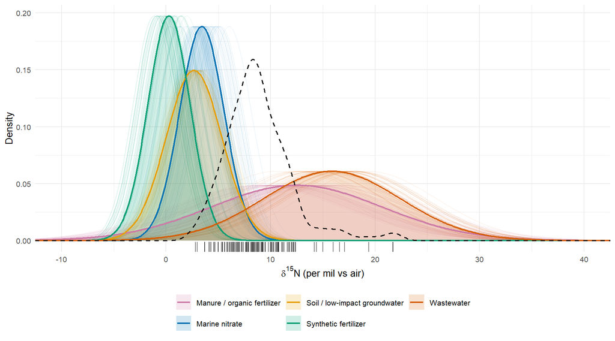

Figure 7

```r
em_lab <- c(wastewater = "Wastewater", manure = "Manure / organic fertilizer",
            synthetic_fertilizer = "Synthetic fertilizer", soil_background = "Soil / low-impact groundwater",
            marine_nitrate = "Marine nitrate")
em_cols <- c(wastewater = "#D55E00", manure = "#CC79A7", synthetic_fertilizer = "#009E73",
             soil_background = "#E69F00", marine_nitrate = "#0072B2")
xg <- seq(-15, 45, length.out = 600)
em_dens <- em_priors |>
  rowwise() |>
  mutate(d = list(tibble(x = xg, y = dnorm(xg, mean, source_sd)))) |>
  ungroup() |> select(group, d) |> unnest(d)
set.seed(SEED)
em_unc <- em_priors |>
  rowwise() |>
  mutate(d = list(map_dfr(1:60, \(r) {
    m <- rnorm(1, mean, se_group_mean)
    tibble(draw = r, x = xg, y = dnorm(xg, m, source_sd))
  }))) |>
  ungroup() |> select(group, d) |> unnest(d)
ggplot() +
  geom_line(data = em_unc, aes(x, y, group = interaction(group, draw), color = group), alpha = 0.12, linewidth = 0.3) +
  geom_area(data = em_dens, aes(x, y, fill = group), alpha = 0.18, position = "identity") +
  geom_line(data = em_dens, aes(x, y, color = group), linewidth = 0.8) +
  geom_density(data = water_iso, aes(N15), color = "black", linetype = "dashed", linewidth = 0.7, show.legend = FALSE) +
  geom_rug(data = water_iso, aes(N15), sides = "b", alpha = 0.5, length = unit(0.04, "npc"), show.legend = FALSE) +
  scale_color_manual(values = em_cols, labels = em_lab, name = NULL) +
  scale_fill_manual(values = em_cols, labels = em_lab, name = NULL) +
  coord_cartesian(xlim = c(-10, 40)) +
  labs(x = expression(delta^{15}*N~"(per mil vs air)"), y = "Density") +
  guides(color = guide_legend(nrow = 2), fill = guide_legend(nrow = 2)) +
  theme_minimal(base_size = 10) + theme(legend.position = "bottom")
```

The dashed black curve is the density of the 138 observed sample d15N values (rug below).